## Практична робота №9.Стиснення даних. Кодування і декодування Гафмена

# Мета : набути практичних навичок застосування алгоритму оптимального кодування Гафмена.

# 1 . Маємо текст ABACABBCACBCABADABAC. Закодувати текст, використовуючи алгоритм Гафмена. Побудувати двійкове дерево. Оцінити ефект від кодування порівняно з неоптимальним випадком

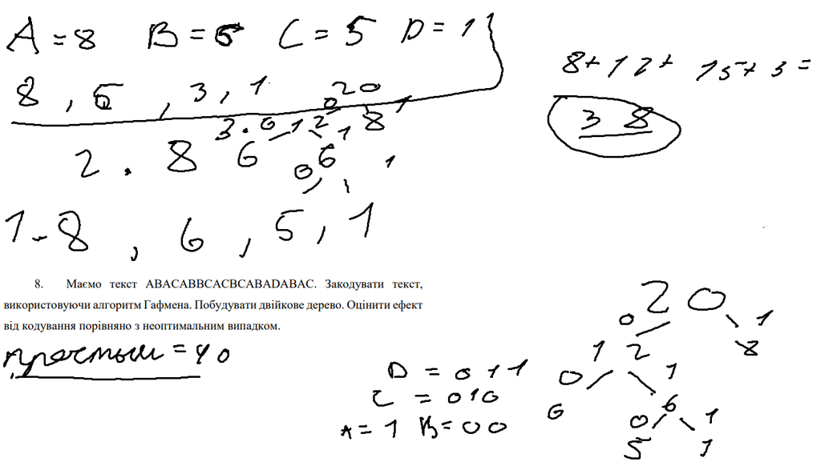

# 2 . Контрольні питання.

- Що таке кодування Гафмена та як воно працює? - Це алгоритм стиснення даних без утрат, який використовує префіксні коди для кодування символів. Для побудови оптимального двійкового коду Гафмена спочатку потрібно відсортувати символи за їх імовірностями від найменшої до найбільшої.Створюємо початкові вузли для кожного символу та їх ймовірностей.Об’єднуємо два вузли з найменшими ймовірностями (найменшою вагою) в один вузол, зберігши їхню сумарну ймовірність, повторюємо це доки не залишиться лише один вузол.Із побудованого дерева взяти дві гілки: ліву гілку позначити як 0, праву - як 1.Отримані двійкові коди для кожного символу є оптимальними двійковими кодами Гафмена.
- Як визначається оптимальний двійковий код Гафмена для стиснення даних? - Для кожного символу код утворюється шляхом проходження від кореня дерева до вузла.Послідовність бітів присвоєних ребрам на шляху і є кодом.
- Які переваги має кодування Гафмена над іншими методами стиснення даних? - оптимальність , простота реалізації , адаптивність.
- Як відбувається декодування даних, закодованих за допомогою кодування Гафмена? - Починаючи з кореня дерева зчитуємо біти стиснутих даних.Процес переміщення по дереву триває до тих пір, поки не буде досягнуто листкового вузла.Якщо зчитаний біт дорівнює 0 , то здійснюється перехід до лівого вузла , якщо біт дорівнює 1 , то до правого вузла.Кожен вузол у дереві Гафмена представляє один з оригінальних символів.
- Які є можливі недоліки кодування Гафмена? - не завжди дає оптимальне стиснення, складність кодування та декодування може бути високою.
- Для чого використовується побудова дерева в кодуванні Гафмена? - для візуалізації та визначення кодових слів змінної довжини для кожного символу.

# 3 . Висновок

На цьому практичному занятті ми набули практичних навичок застосування алгоритму оптимального кодування Гафмена.